**MNIST Classification with ANN**

By Prof. Seungchul Lee  
http://iai.postech.ac.kr/  
Industrial AI Lab at POSTECH

# 1. What's an MNIST?

From Wikipedia

- The MNIST database (Mixed National Institute of Standards and Technology database) is a large database of handwritten digits that is commonly used for training various image processing systems. The database is also widely used for training and testing in the field of machine learning. It was created by "re-mixing" the samples from NIST's original datasets. The creators felt that since NIST's training dataset was taken from American Census Bureau employees, while the testing dataset was taken from American high school students, NIST's complete dataset was too hard.
- MNIST (Mixed National Institute of Standards and Technology database) database
  - Handwritten digit database
  - $28 \times 28$ gray scaled image
  - Flattened matrix into a vector of $28 \times 28 = 784$

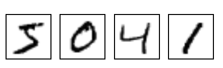

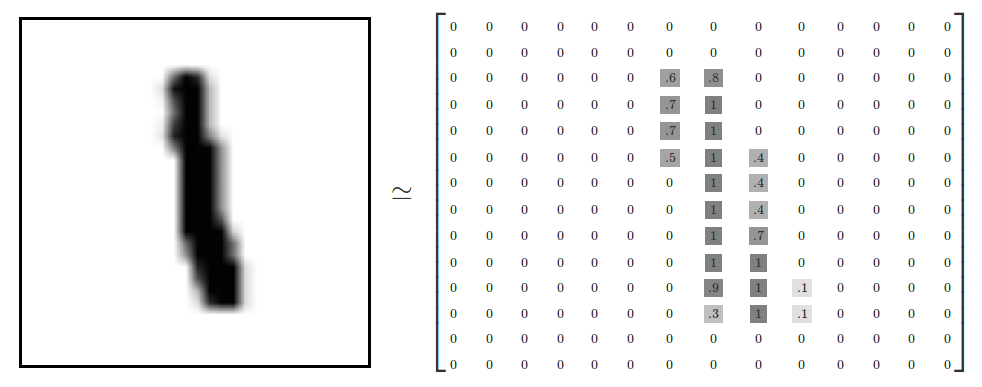

More here

- http://yann.lecun.com/exdb/mnist/

We will be using MNIST to create a Multinomial Classifier that can detect if the MNIST image shown is a member of class 0,1,2,3,4,5,6,7,8 or 9. Susinctly, we're teaching a computer to recognize hand written digets.

```python
# Import Library
import numpy as np
import matplotlib.pyplot as plt
import tensorflow as tf
%matplotlib inline
```

Let's download and load the dataset.

```python
from tensorflow.examples.tutorials.mnist import input_data
mnist = input_data.read_data_sets("MNIST_data/", one_hot=True)
```

[output not shown]

```
Extracting MNIST_data/train-images-idx3-ubyte.gz
```

[output not shown]

```
Extracting MNIST_data/train-labels-idx1-ubyte.gz
Extracting MNIST_data/t10k-images-idx3-ubyte.gz
Extracting MNIST_data/t10k-labels-idx1-ubyte.gz
```

```python
print ("The training data set is:\n")
print (mnist.train.images.shape)
print (mnist.train.labels.shape)
```

```
The training data set is:

(55000, 784)
(55000, 10)
```

```python
print ("The test data set is:")
print (mnist.test.images.shape)
print (mnist.test.labels.shape)
```

```
The test data set is:
(10000, 784)
(10000, 10)
```

Display a few random samples from it:

```python
mnist.train.images[5]
```

[output not shown]

[output cut: 102 more lines]

[output not shown]

```python
# well, that's not a picture (or image), it's an array.

mnist.train.images[5].shape
```

```
(784,)
```

You might think the training set is made up of 28 $\times$28 grayscale images of handwritten digits. No !!!

The thing is, the image has been flattened. These are 28x28 images that have been flattened into a 1D array. Let's reshape one.

```python
img = np.reshape(mnist.train.images[5], [28,28])
```

```python
img = mnist.train.images[5].reshape([28,28])
```

```python
# So now we have a 28x28 matrix, where each element is an intensity level from 0 to 1.
img.shape
```

```
(28, 28)
```

Let's visualize what some of these images and their corresponding training labels look like.

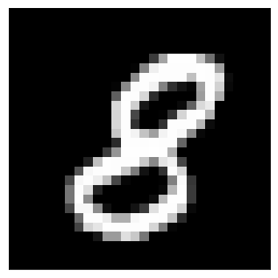

```python
plt.figure(figsize = (6,6))
plt.imshow(img, 'gray')
plt.xticks([])
plt.yticks([])
plt.show()
```

One-hot encoding

- https://machinelearningmastery.com/why-one-hot-encode-data-in-machine-learning/

```python
mnist.train.labels[5]
```

```
array([0., 0., 0., 0., 0., 0., 0., 0., 1., 0.])
```

```python
np.argmax(mnist.train.labels[5])
```

```
8
```

Batch maker embedded

```python
x, y = mnist.train.next_batch(3)

print(x.shape)
print(y.shape)
```

```
(3, 784)
(3, 10)
```

# 2. ANN with TensorFlow

- Feed a gray image to ANN

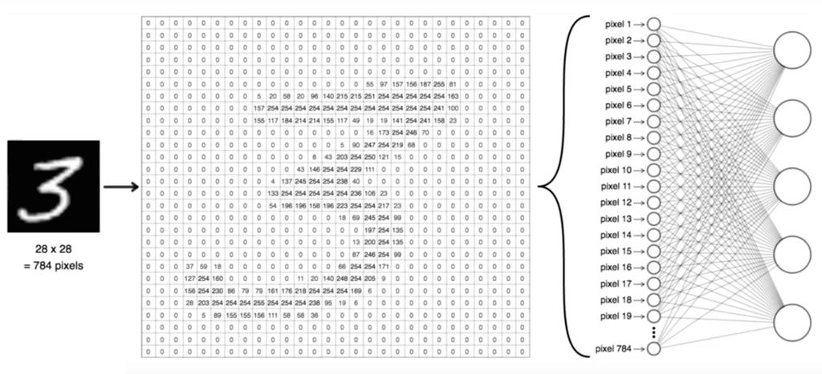

- Our network model

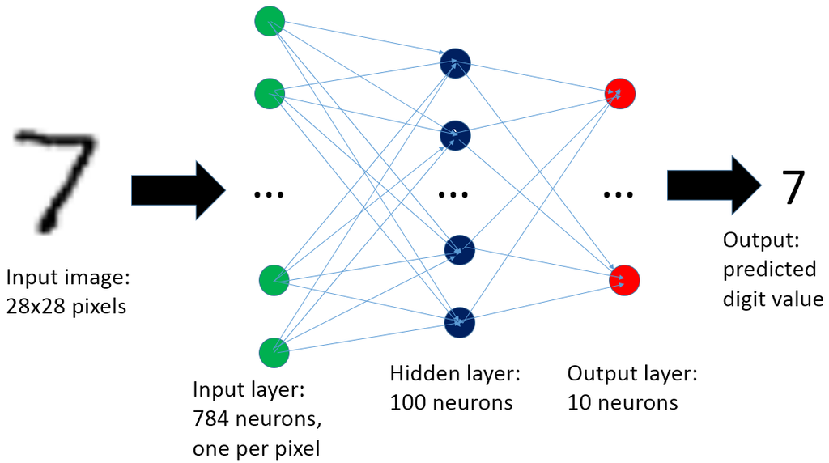

- Network training (learning) $$\omega:= \omega - \alpha \nabla_{\omega} \left( h_{\omega} \left(x^{(i)}\right),y^{(i)}\right)$$

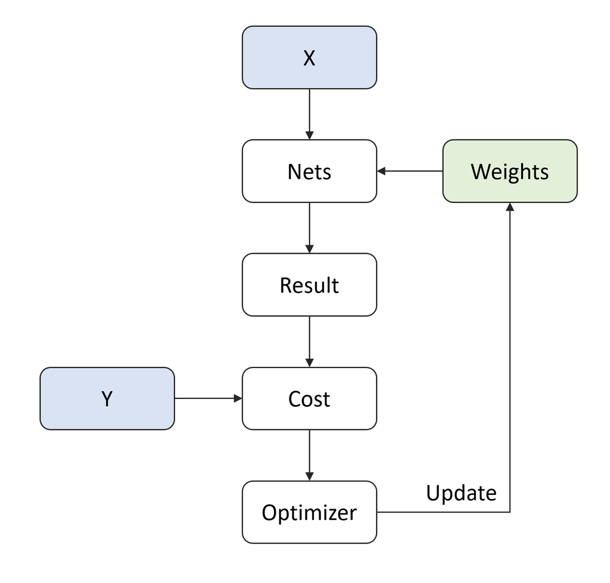

## 2.1. Import Library

```python
# Import Library
import numpy as np
import matplotlib.pyplot as plt
import tensorflow as tf
```

## 2.2. Load MNIST Data

- Download MNIST data from tensorflow tutorial example

```python
from tensorflow.examples.tutorials.mnist import input_data

mnist = input_data.read_data_sets("MNIST_data/", one_hot=True)
```

```
Extracting MNIST_data/train-images-idx3-ubyte.gz
Extracting MNIST_data/train-labels-idx1-ubyte.gz
Extracting MNIST_data/t10k-images-idx3-ubyte.gz
Extracting MNIST_data/t10k-labels-idx1-ubyte.gz
```

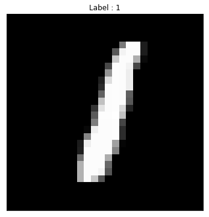

```python
train_x, train_y = mnist.train.next_batch(1)
img = train_x[0,:].reshape(28,28)

plt.figure(figsize=(6,6))
plt.imshow(img,'gray')
plt.title("Label : {}".format(np.argmax(train_y[0,:])))
plt.xticks([])
plt.yticks([])
plt.show()
```

One hot encoding

```python
print ('Train labels : {}'.format(train_y[0, :]))
```

```
Train labels : [0. 1. 0. 0. 0. 0. 0. 0. 0. 0.]
```

## 2.3. Define an ANN Structure

- Input size
- Hidden layer size
- The number of classes

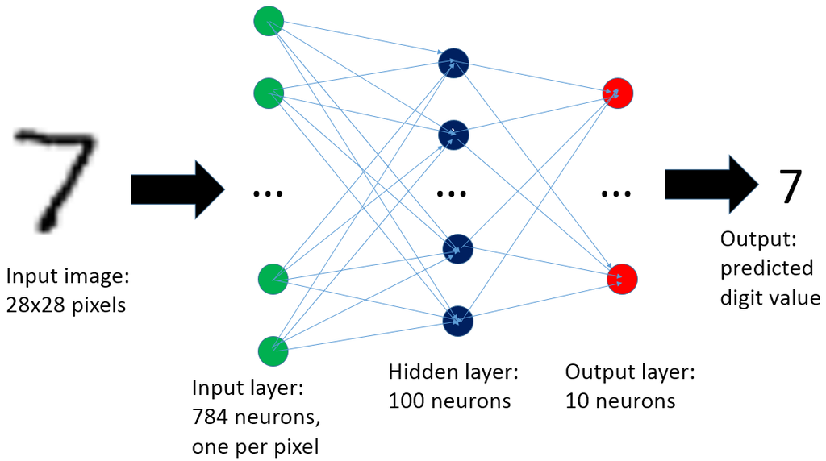

```python
n_input = 28*28
n_hidden = 100
n_output = 10
```

## 2.4. Define Weights, Biases, and Placeholder

- Define parameters based on predefined layer size
- Initialize with normal distribution with $\mu = 0$ and $\sigma = 0.1$

```python
weights = {
    'hidden' : tf.Variable(tf.random_normal([n_input, n_hidden], stddev = 0.1)),
    'output' : tf.Variable(tf.random_normal([n_hidden, n_output], stddev = 0.1))
}

biases = {
    'hidden' : tf.Variable(tf.random_normal([n_hidden], stddev = 0.1)),
    'output' : tf.Variable(tf.random_normal([n_output], stddev = 0.1))
}
```

```python
x = tf.placeholder(tf.float32, [None, n_input])
y = tf.placeholder(tf.float32, [None, n_output])
```

## 2.5. Build a Model

**First, the layer performs several matrix multiplication to produce a set of linear activations**

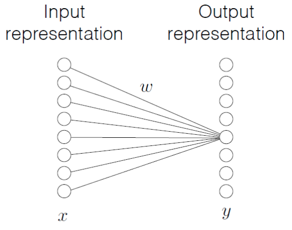

$$y_j = \left(\sum\limits_i \omega_{ij}x_i\right) + b_j$$$$\mathcal{y} = \omega^T \mathcal{x} + \mathcal{b}$$

**Second, each linear activation is running through a nonlinear activation function**

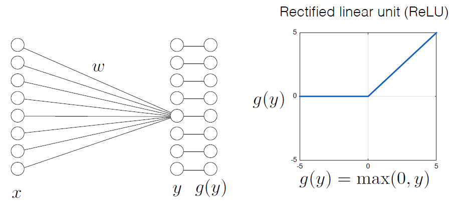

**Third, predict values with an affine transformation**

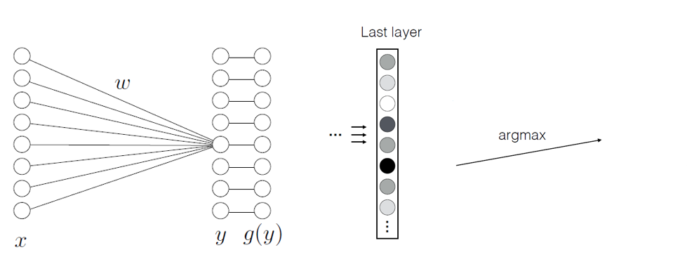

```python
# Define Network
def build_model(x, weights, biases):

    # first hidden layer
    hidden = tf.add(tf.matmul(x, weights['hidden']), biases['hidden'])
    # non-linear activate function
    hidden = tf.nn.relu(hidden)

    # Output layer
    output = tf.add(tf.matmul(hidden, weights['output']), biases['output'])

    return output
```

## 2.6. Define Loss and Optimizer

**Loss**

- This defines how we measure how accurate the model is during training. As was covered in lecture, during training we want to minimize this function, which will "steer" the model in the right direction.
- Classification: Cross entropy
  - Equivalent to apply logistic regression

$$ -\frac{1}{m}\sum_{i=1}^{m}y^{(i)}\log(h_{\theta}\left(x^{(i)}\right)) + (1-y^{(i)})\log(1-h_{\theta}\left(x^{(i)}\right)) $$

**Optimizer**

- This defines how the model is updated based on the data it sees and its loss function.
- AdamOptimizer: the most popular optimizer

```python
# Define Loss
pred = build_model(x, weights, biases)
loss = tf.nn.softmax_cross_entropy_with_logits(logits = pred, labels = y)
loss = tf.reduce_mean(loss)

LR = 0.0001
optm = tf.train.AdamOptimizer(LR).minimize(loss)
```

[output not shown]

## 2.7. Define Optimization Configuration and Then Optimize

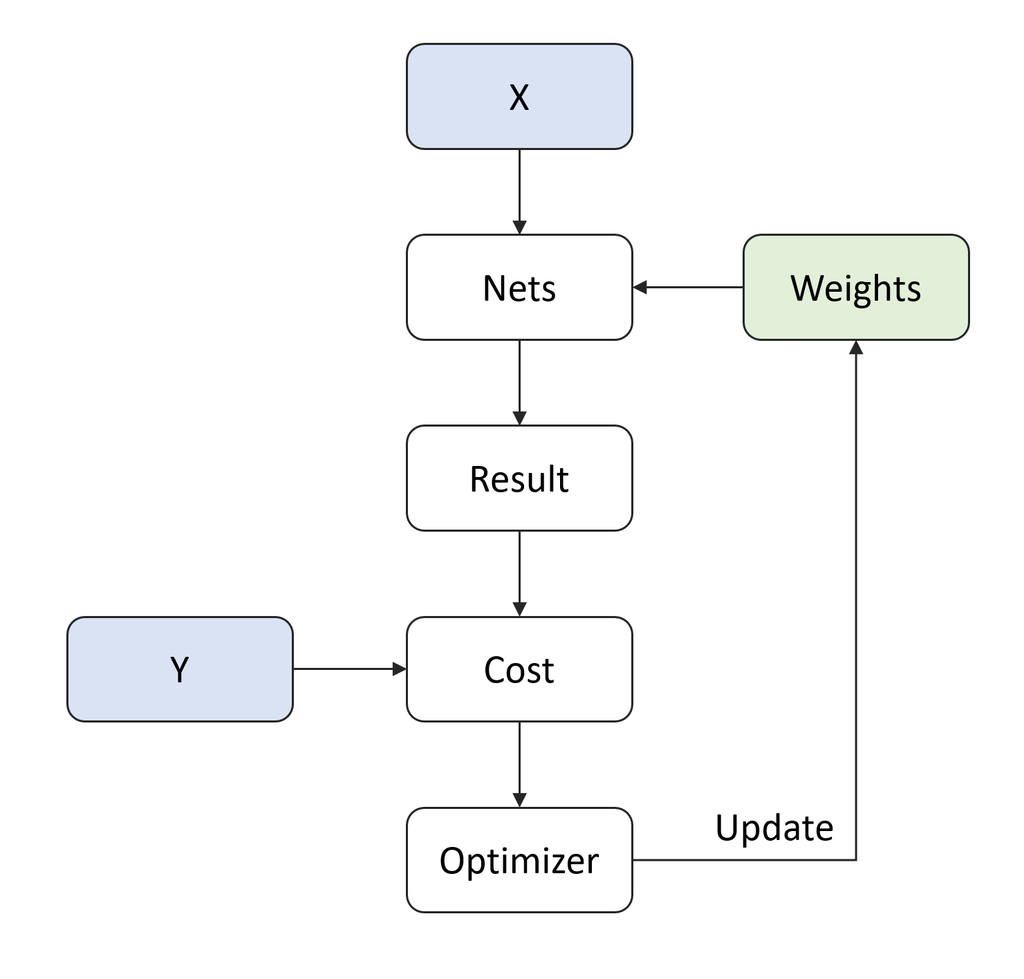

- Define parameters for training ANN
  - `n_batch`: batch size for mini-batch gradient descent
  - `n_iter`: the number of iteration steps
  - `n_prt`: check loss for every `n_prt` iteration
- Metrics
  - Here we can define metrics used to monitor the training and testing steps. In this example, we'll look at the accuracy, the fraction of the images that are correctly classified.

**Initializer**

- Initialize all the variables

```python
n_batch = 50     # Batch Size
n_iter = 5000    # Learning Iteration
n_prt = 250      # Print Cycle
```

```
Iter : 0
Cost : 2.5226938724517822
Iter : 250
Cost : 1.2091383934020996
Iter : 500
Cost : 0.6632410287857056
Iter : 750
Cost : 0.5070315003395081
Iter : 1000
Cost : 0.6699517965316772
Iter : 1250
Cost : 0.5949968695640564
Iter : 1500
Cost : 0.4127747714519501
Iter : 1750
Cost : 0.38207876682281494
Iter : 2000
Cost : 0.2780102789402008
Iter : 2250
Cost : 0.4373106360435486
Iter : 2500
Cost : 0.21637916564941406
Iter : 2750
Cost : 0.44592857360839844
Iter : 3000
Cost : 0.5851737856864929
Iter : 3250
Cost : 0.30456820130348206
Iter : 3500
Cost : 0.2559150755405426
Iter : 3750
Cost : 0.371742844581604
Iter : 4000
Cost : 0.20414051413536072
Iter : 4250
Cost : 0.20037569105625153
Iter : 4500
Cost : 0.17589792609214783
Iter : 4750
Cost : 0.2978155016899109
```

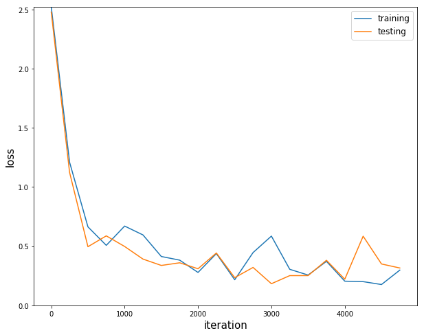

```python
sess = tf.Session()
init = tf.global_variables_initializer()
sess.run(init)

loss_record_train = []
loss_record_test = []
for epoch in range(n_iter):
    train_x, train_y = mnist.train.next_batch(n_batch)
    sess.run(optm, feed_dict = {x: train_x, y: train_y})

    if epoch % n_prt == 0:
        test_x, test_y = mnist.test.next_batch(n_batch)
        c1 = sess.run(loss, feed_dict = {x: train_x, y: train_y})
        c2 = sess.run(loss, feed_dict = {x: test_x, y: test_y})
        loss_record_train.append(c1)
        loss_record_test.append(c2)
        print ("Iter : {}".format(epoch))
        print ("Cost : {}".format(c1))

plt.figure(figsize=(10,8))
plt.plot(np.arange(len(loss_record_train))*n_prt,
         loss_record_train, label = 'training')
plt.plot(np.arange(len(loss_record_test))*n_prt,
         loss_record_test, label = 'testing')
plt.xlabel('iteration', fontsize = 15)
plt.ylabel('loss', fontsize = 15)
plt.legend(fontsize = 12)
plt.ylim([0, np.max(loss_record_train)])
plt.show()
```

## 2.8. Test or Evaluate

```python
test_x, test_y = mnist.test.next_batch(100)

my_pred = sess.run(pred, feed_dict = {x : test_x})
my_pred = np.argmax(my_pred, axis = 1)

labels = np.argmax(test_y, axis = 1)

accr = np.mean(np.equal(my_pred, labels))
print("Accuracy : {}%".format(accr*100))
```

```
Accuracy : 92.0%
```

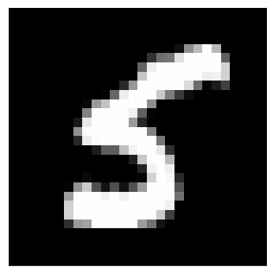

```
Prediction : 5
Probability : [0.   0.   0.   0.   0.   0.99 0.   0.   0.01 0.  ]
```

```python
test_x, test_y = mnist.test.next_batch(1)
logits = sess.run(tf.nn.softmax(pred), feed_dict = {x : test_x})
predict = np.argmax(logits)

plt.figure(figsize = (6,6))
plt.imshow(test_x.reshape(28,28), 'gray')
plt.xticks([])
plt.yticks([])
plt.show()

print('Prediction : {}'.format(predict))
np.set_printoptions(precision = 2, suppress = True)
print('Probability : {}'.format(logits.ravel()))
```

What is the highest accuracy you can achieve with this first fully connected model? Since the handwritten digit classification task is pretty straightforward, you may be wondering how we can do better...

$\Rightarrow$ As we saw in lecture, convolutional neural networks (CNNs) are particularly well-suited for a variety of tasks in computer vision, and have achieved near-perfect accuracies on the MNIST dataset. We will build a CNN and ultimately output a probability distribution over the 10 digit classes (0-9) in the next lectures.

```python
%%javascript
$.getScript('https://kmahelona.github.io/ipython_notebook_goodies/ipython_notebook_toc.js')
```